# DS 220 Project #2

Carter Rowe

The dataset can be found at https://www.lock5stat.com/datapage2e.html

# **Data Visualization with Matplotlib ans US States Database**

The "USStates.csv" database provides a comprehensive overview of various demographic, economic, educational, and health-related statistics for each state in the United States. It includes data on household income, population, educational achievement (such as eighth-grade math scores and high school completion rates), and college attendance. The database also covers health and lifestyle metrics like average IQ, obesity rates, smoking prevalence, and the percentage of the population engaging in physical activities or consuming recommended daily amounts of vegetables and fruits. Additionally, it contains economic indicators like Gross State Product (GSP), along with political and demographic information, including electoral votes, election outcomes, racial composition, and family structures. This rich dataset is invaluable for policymakers, researchers, and economists, offering insights that can help in crafting targeted policies, conducting socio-economic analyses, and understanding regional disparities across the United States.

```python
import pandas as pd
df = pd.read_csv('USStates.csv', encoding='cp1252')
df
```

|  | State | HouseholdIncome | Region | Population | EighthGradeMath | HighSchool | College | IQ | GSP | Vegetables | ... | PhysicalActivity | Obese | NonWhite | HeavyDrinkers | Electoral | ObamaVote | ObamaRomney | TwoParents | StudentSpending | Insured |
| --- | --- | --- | --- | --- | --- | --- | --- | --- | --- | --- | --- | --- | --- | --- | --- | --- | --- | --- | --- | --- | --- |
| 0 | Alabama | 43.253 | S | 4.849 | 269.2 | 84.9 | 24.9 | 95.7 | 32.615 | 74.2 | ... | 45.4 | 32.4 | 30.7 | 4.3 | 9 | 0.384 | R | 58.7 | 8.755 | 78.8 |
| 1 | Alaska | 70.760 | W | 0.737 | 281.6 | 92.8 | 24.7 | 99.0 | 61.156 | 80.8 | ... | 55.3 | 28.4 | 33.1 | 8.2 | 3 | 0.408 | R | 69.6 | 18.175 | 79.8 |
| 2 | Arizona | 49.774 | W | 6.731 | 279.7 | 85.6 | 25.5 | 97.4 | 35.195 | 76.2 | ... | 51.9 | 26.8 | 20.8 | 6.3 | 11 | 0.446 | R | 62.7 | 7.208 | 74.7 |
| 3 | Arkansas | 40.768 | S | 2.966 | 277.9 | 87.1 | 22.4 | 97.5 | 31.837 | 72.0 | ... | 41.2 | 34.6 | 21.7 | 5.0 | 6 | 0.369 | R | 62.0 | 9.394 | 71.7 |
| 4 | California | 61.094 | W | 38.803 | 275.9 | 84.1 | 31.4 | 95.5 | 46.029 | 82.7 | ... | 56.3 | 24.1 | 37.7 | 6.4 | 55 | 0.602 | O | 65.3 | 9.220 | 79.7 |
| 5 | Colorado | 58.433 | W | 5.356 | 289.7 | 89.5 | 37.0 | 101.6 | 46.242 | 80.9 | ... | 60.4 | 21.3 | 15.8 | 6.7 | 9 | 0.515 | O | 69.9 | 8.647 | 80.0 |
| 6 | Connecticut | 69.461 | NE | 3.597 | 285.2 | 91.0 | 39.8 | 103.1 | 54.925 | 77.8 | ... | 50.9 | 25.0 | 22.1 | 6.3 | 7 | 0.581 | O | 67.0 | 16.631 | 87.7 |
| 7 | Delaware | 59.878 | NE | 0.936 | 282.3 | 86.9 | 31.7 | 100.4 | 61.183 | 71.1 | ... | 49.7 | 31.1 | 30.0 | 6.6 | 3 | 0.586 | O | 60.4 | 13.833 | 85.7 |
| 8 | Florida | 46.956 | S | 19.893 | 280.9 | 87.1 | 26.5 | 98.4 | 34.802 | 79.2 | ... | 50.2 | 26.4 | 23.7 | 7.2 | 29 | 0.500 | O | 60.2 | 8.433 | 70.9 |
| 9 | Georgia | 49.179 | S | 10.097 | 279.2 | 85.3 | 29.0 | 98.0 | 37.702 | 76.3 | ... | 50.8 | 30.3 | 39.4 | 4.7 | 16 | 0.455 | R | 60.3 | 9.099 | 72.7 |
| 10 | Hawaii | 67.402 | W | 1.420 | 281.4 | 94.8 | 29.7 | 95.6 | 44.442 | 76.9 | ... | 60.2 | 21.8 | 75.0 | 7.6 | 4 | 0.705 | O | 70.4 | 11.823 | 90.0 |
| 11 | Idaho | 46.767 | W | 1.634 | 286.4 | 89.9 | 23.6 | 101.4 | 31.945 | 79.6 | ... | 53.9 | 29.6 | 8.1 | 6.2 | 4 | 0.326 | R | 74.1 | 6.791 | 75.9 |
| 12 | Illinois | 56.797 | MW | 12.881 | 284.9 | 89.8 | 38.2 | 99.9 | 46.151 | 76.0 | ... | 52.4 | 29.4 | 27.5 | 6.5 | 20 | 0.576 | O | 66.2 | 12.288 | 80.6 |
| 13 | Indiana | 48.248 | MW | 6.597 | 287.8 | 87.6 | 27.5 | 101.7 | 39.065 | 73.1 | ... | 44.1 | 31.8 | 15.4 | 5.2 | 11 | 0.439 | R | 65.4 | 9.566 | 79.1 |
| 14 | Iowa | 51.843 | MW | 3.107 | 285.1 | 92.4 | 32.2 | 103.2 | 42.222 | 73.2 | ... | 47.0 | 31.3 | 8.5 | 6.5 | 6 | 0.520 | O | 69.6 | 10.313 | 87.3 |
| 15 | Kansas | 51.332 | MW | 2.904 | 289.5 | 89.6 | 33.1 | 102.8 | 41.070 | 77.1 | ... | 49.1 | 30.0 | 14.6 | 4.6 | 6 | 0.380 | R | 70.0 | 9.828 | 79.2 |
| 16 | Kentucky | 43.036 | MW | 4.413 | 280.6 | 88.5 | 25.7 | 99.4 | 33.519 | 75.1 | ... | 46.0 | 33.2 | 12.1 | 4.9 | 8 | 0.378 | R | 64.3 | 9.316 | 78.0 |
| 17 | Louisiana | 44.874 | S | 4.650 | 272.8 | 85.0 | 25.0 | 95.3 | 43.145 | 67.3 | ... | 45.2 | 33.1 | 37.1 | 6.3 | 8 | 0.406 | R | 54.1 | 10.490 | 74.0 |
| 18 | Maine | 48.453 | NE | 1.330 | 288.7 | 94.0 | 29.9 | 103.4 | 34.597 | 82.3 | ... | 53.6 | 28.9 | 4.8 | 7.2 | 4 | 0.563 | O | 66.1 | 12.147 | 84.7 |
| 19 | Maryland | 73.538 | NE | 5.976 | 286.6 | 89.5 | 39.4 | 99.7 | 46.720 | 78.0 | ... | 48.6 | 28.3 | 41.6 | 5.2 | 10 | 0.620 | O | 63.7 | 13.829 | 84.5 |
| 20 | Massachusetts | 66.866 | NE | 6.745 | 300.6 | 92.4 | 48.3 | 104.3 | 53.221 | 79.9 | ... | 54.5 | 23.6 | 19.5 | 7.5 | 11 | 0.607 | O | 67.6 | 14.515 | 92.8 |
| 21 | Michigan | 48.411 | MW | 9.910 | 280.1 | 90.0 | 29.2 | 100.5 | 35.298 | 75.2 | ... | 53.1 | 31.5 | 20.7 | 6.3 | 16 | 0.542 | O | 64.1 | 10.948 | 82.6 |
| 22 | Minnesota | 59.836 | MW | 5.457 | 294.6 | 92.8 | 38.0 | 103.7 | 47.028 | 76.4 | ... | 52.7 | 25.5 | 14.4 | 7.3 | 10 | 0.527 | O | 71.2 | 11.089 | 87.1 |
| 23 | Mississippi | 39.031 | S | 2.994 | 271.2 | 84.2 | 21.1 | 94.2 | 28.944 | 69.4 | ... | 37.4 | 35.1 | 40.5 | 4.2 | 6 | 0.438 | R | 52.3 | 8.130 | 71.9 |
| 24 | Missouri | 47.380 | MW | 6.064 | 283.0 | 90.0 | 31.2 | 101.0 | 36.815 | 75.7 | ... | 48.7 | 30.4 | 17.0 | 6.0 | 10 | 0.444 | R | 65.5 | 9.597 | 81.2 |
| 25 | Montana | 46.230 | W | 1.024 | 289.2 | 92.5 | 31.1 | 103.4 | 33.204 | 79.5 | ... | 57.8 | 24.6 | 10.6 | 7.7 | 3 | 0.417 | R | 67.0 | 10.625 | 78.5 |
| 26 | Nebraska | 51.672 | MW | 1.882 | 285.1 | 90.1 | 33.3 | 102.3 | 44.943 | 76.7 | ... | 50.1 | 29.6 | 11.8 | 6.8 | 5 | 0.380 | R | 70.5 | 11.579 | 82.4 |
| 27 | Nevada | 52.800 | W | 2.839 | 278.3 | 83.9 | 21.5 | 96.5 | 41.029 | 79.2 | ... | 53.6 | 26.2 | 28.6 | 7.1 | 6 | 0.524 | O | 62.7 | 8.339 | 72.7 |
| 28 | New Hampshire | 64.916 | NE | 1.327 | 295.7 | 93.0 | 36.5 | 104.2 | 42.958 | 83.2 | ... | 55.4 | 26.7 | 6.0 | 6.5 | 4 | 0.520 | O | 69.6 | 13.721 | 84.4 |
| 29 | New Jersey | 71.629 | NE | 8.938 | 296.1 | 90.7 | 41.5 | 102.8 | 49.430 | 78.6 | ... | 50.5 | 26.3 | 30.8 | 5.0 | 14 | 0.584 | O | 69.2 | 17.572 | 80.7 |
| 30 | New Mexico | 44.927 | W | 2.086 | 272.8 | 84.0 | 21.4 | 95.7 | 33.900 | 78.5 | ... | 55.0 | 26.4 | 27.0 | 5.9 | 5 | 0.530 | O | 56.6 | 9.012 | 73.8 |
| 31 | New York | 58.003 | NE | 19.746 | 281.8 | 88.4 | 41.9 | 100.7 | 53.067 | 78.0 | ... | 47.3 | 25.4 | 34.4 | 6.0 | 29 | 0.633 | O | 64.2 | 19.818 | 83.0 |
| 32 | North Carolina | 46.334 | S | 9.944 | 285.6 | 85.8 | 30.2 | 100.2 | 40.289 | 77.6 | ... | 48.6 | 29.4 | 30.3 | 4.9 | 15 | 0.484 | R | 61.9 | 8.390 | 75.8 |
| 33 | North Dakota | 53.741 | MW | 0.739 | 290.5 | 95.4 | 33.9 | 103.8 | 55.250 | 72.6 | ... | 45.3 | 31.0 | 10.4 | 7.2 | 3 | 0.387 | R | 72.5 | 11.980 | 87.6 |
| 34 | Ohio | 48.308 | MW | 11.594 | 289.5 | 90.3 | 30.3 | 101.8 | 37.690 | 73.7 | ... | 49.5 | 30.4 | 17.1 | 5.7 | 18 | 0.507 | O | 63.4 | 11.197 | 83.3 |
| 35 | Oklahoma | 45.339 | S | 3.878 | 275.5 | 87.3 | 24.6 | 99.3 | 36.252 | 74.7 | ... | 43.9 | 32.5 | 26.5 | 4.2 | 7 | 0.332 | R | 64.4 | 7.672 | 77.4 |
| 36 | Oregon | 50.229 | W | 3.970 | 283.5 | 88.7 | 30.1 | 101.2 | 48.069 | 83.7 | ... | 64.1 | 26.5 | 14.8 | 8.6 | 7 | 0.542 | O | 69.0 | 9.543 | 75.0 |
| 37 | Pennsylvania | 52.548 | NE | 12.787 | 289.6 | 91.4 | 35.7 | 101.5 | 40.063 | 75.3 | ... | 47.8 | 30.0 | 17.8 | 5.9 | 20 | 0.520 | O | 65.1 | 13.864 | 84.8 |
| 38 | Rhode Island | 56.361 | NE | 1.055 | 284.1 | 89.3 | 35.7 | 99.5 | 41.678 | 78.7 | ... | 49.1 | 27.3 | 18.6 | 6.1 | 4 | 0.627 | O | 59.1 | 14.415 | 81.3 |
| 39 | South Carolina | 44.779 | S | 4.832 | 279.8 | 86.3 | 27.3 | 98.4 | 31.881 | 73.2 | ... | 49.1 | 31.7 | 32.8 | 5.7 | 9 | 0.441 | R | 58.3 | 9.514 | 76.1 |
| 40 | South Dakota | 49.495 | MW | 0.853 | 287.3 | 92.2 | 29.1 | 102.8 | 43.181 | 75.5 | ... | 53.7 | 29.9 | 14.4 | 5.2 | 3 | 0.399 | R | 67.5 | 8.470 | 85.1 |
| 41 | Tennessee | 44.298 | S | 6.549 | 277.7 | 88.6 | 27.5 | 97.7 | 37.254 | 75.7 | ... | 37.7 | 33.7 | 21.8 | 3.3 | 11 | 0.391 | R | 62.1 | 8.208 | 78.8 |
| 42 | Texas | 51.900 | S | 26.957 | 288.2 | 83.8 | 26.9 | 100.0 | 46.498 | 78.5 | ... | 42.1 | 30.9 | 25.6 | 5.9 | 38 | 0.414 | R | 64.4 | 8.299 | 67.3 |
| 43 | Utah | 58.821 | W | 2.943 | 284.3 | 91.2 | 29.9 | 101.1 | 39.158 | 79.6 | ... | 55.3 | 24.1 | 11.6 | 4.5 | 6 | 0.247 | R | 80.6 | 6.555 | 80.8 |
| 44 | Vermont | 54.267 | NE | 0.627 | 295.5 | 93.4 | 37.2 | 103.8 | 38.198 | 83.5 | ... | 58.8 | 24.7 | 4.8 | 7.1 | 3 | 0.666 | O | 67.1 | 16.377 | 88.5 |
| 45 | Virginia | 63.907 | S | 8.326 | 288.1 | 90.8 | 38.9 | 101.9 | 47.127 | 78.6 | ... | 51.9 | 27.2 | 30.5 | 5.7 | 13 | 0.512 | O | 67.9 | 10.960 | 81.6 |
| 46 | Washington | 59.478 | W | 7.062 | 290.0 | 89.5 | 31.9 | 101.9 | 47.146 | 81.8 | ... | 56.3 | 27.2 | 21.5 | 6.6 | 12 | 0.562 | O | 69.7 | 9.672 | 79.4 |
| 47 | West Virginia | 41.043 | S | 1.850 | 274.4 | 90.2 | 23.2 | 98.7 | 30.389 | 75.8 | ... | 47.6 | 35.1 | 6.2 | 3.9 | 5 | 0.355 | R | 62.8 | 11.132 | 76.3 |
| 48 | Wisconsin | 52.413 | MW | 5.758 | 288.7 | 91.7 | 31.2 | 102.9 | 39.308 | 74.2 | ... | 53.4 | 29.8 | 13.0 | 7.8 | 10 | 0.528 | O | 68.6 | 11.071 | 85.8 |
| 49 | Wyoming | 57.406 | W | 0.584 | 288.1 | 92.7 | 25.7 | 102.4 | 54.305 | 79.9 | ... | 54.2 | 27.8 | 9.1 | 5.8 | 3 | 0.278 | R | 71.3 | 15.700 | 76.4 |

50 rows × 22 columns

1. **What state has the highest IQ?**

```python
data = pd.read_csv('USStates.csv')

# Finding the state with the highest IQ
highest_iq_state = data.loc[data['IQ'].idxmax(), 'State']

print("State with the highest IQ:")
print(highest_iq_state)
```

```
State with the highest IQ:
Massachusetts
```

Identifying the state with the highest IQ in the "USStates.csv" database can reveal connections between intelligence and socioeconomic factors such as education quality, income levels, and access to cognitive development resources. This insight might help policymakers understand which practices are effective in boosting cognitive performance and can guide educational and economic strategies. Essentially, higher IQ scores not only reflect the intellectual capacity of a region but also influence its economic and developmental policies.

2. **How many electoral votes does Colorado have, and which presidential candidate did it vote for in the last election?**

```python
import pandas as pd

# Load the data
nobel = pd.read_csv("USStates.csv")


# Find the electoral votes and last election voting result for Colorado
colorado_election_info = nobel[nobel['State'] == 'Colorado'][['Electoral', 'ObamaRomney']].iloc[0]

print("Colorado has", colorado_election_info['Electoral'], "electoral votes.")
print("In the last election, Colorado voted for:", colorado_election_info['ObamaRomney']," (O) for Obama and (R) for Romney")
```

```
Colorado has 9 electoral votes.
In the last election, Colorado voted for: O  (O) for Obama and (R) for Romney
```

From the question about Colorado's electoral votes and presidential preference, a viewer can understand the state's political significance and alignment during a particular election. Knowing the number of electoral votes highlights Colorado's influence in the electoral process, while identifying the candidate it supported provides insight into the state's political trends. This information is crucial for analyzing regional and national political shifts, understanding voter behavior, and assessing the impact of national policies on state-level voting patterns.

3. **What is the relative size of each region?**

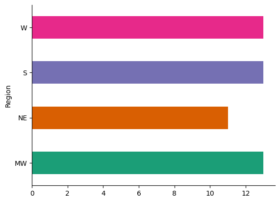

```python
from matplotlib import pyplot as plt
import seaborn as sns
data.groupby('Region').size().plot(kind='barh', color=sns.palettes.mpl_palette('Dark2'))
plt.gca().spines[['top', 'right',]].set_visible(False)
```

4. **What is the average household income of California?**

```python
import pandas as pd
nobel = pd.read_csv("USStates.csv")


# Find the household income for California
california_income = nobel[nobel['State'] == 'California']['HouseholdIncome'].iloc[0]

print("The average household income in California is:", california_income)
```

```
The average household income in California is: 61.094
```

Knowing the average household income of California from the database can provide viewers with valuable insights into the economic status and living standards of the state. This metric helps assess the general prosperity of California residents and can be compared to national averages to gauge economic health. Higher average incomes may indicate a robust job market, higher cost of living, and greater consumer spending potential. Conversely, when juxtaposed with other economic indicators such as poverty rates or housing costs, it can highlight economic disparities and challenges within the state. This information is crucial for policymakers, businesses, and researchers in understanding economic dynamics and planning economic, fiscal, and social policies effectively.

5. **What percent of adults in Arkansas have completed high school?**

```python
import pandas as pd

# Load the data
nobel = pd.read_csv("USStates.csv")


# Find the high school completion rate for Arkansas
arkansas_high_school_rate = nobel[nobel['State'] == 'Arkansas']['HighSchool'].iloc[0]

print("The percentage of adults in Arkansas who have completed high school is:", arkansas_high_school_rate, "%")
```

```
The percentage of adults in Arkansas who have completed high school is: 87.1 %
```

Knowing the percentage of adults in Arkansas who have completed high school provides valuable insights into the state's educational attainment level. This metric can serve as an indicator of the workforce's skill level, impacting employment opportunities, income potential, and economic development. Higher educational attainment can lead to better job prospects and economic stability, while lower rates might highlight challenges such as limited access to education or higher dropout rates. This information is crucial for educators, policymakers, and social planners to address educational barriers and improve workforce readiness. It also helps in understanding broader social issues like poverty and health disparities that are often correlated with education levels.

6. **What is the student spending and percentage of insured residents in Delaware?**

```python
import pandas as pd

# Load the data
nobel = pd.read_csv("USStates.csv")


# Find the student spending and insured percentage for Delaware
delaware_data = nobel[nobel['State'] == 'Delaware'][['StudentSpending', 'Insured']].iloc[0]

print("In Delaware, the student spending is: ${:.2f} and the percentage of insured residents is: {}%".format(delaware_data['StudentSpending'], delaware_data['Insured']))
```

```
In Delaware, the student spending is: $13.83 and the percentage of insured residents is: 85.7%
```

Knowing Delaware's student spending and the percentage of insured residents provides insights into the state's investment in education and healthcare. High student spending often correlates with better educational outcomes and preparedness, while a high percentage of insured residents indicates broad access to healthcare, which improves overall public health. These metrics help viewers assess Delaware’s effectiveness in fostering educational and health well-being and allow for comparisons with other states. This information is crucial for policymakers and health officials to make informed decisions to enhance societal welfare.

7. **Which state has the lowest rate of physical activity, and what is its obesity rate?**

```python
import pandas as pd

# Load the data
nobel = pd.read_csv("USStates.csv")


# Sort the DataFrame by physical activity rate in ascending order
sorted_data = nobel.sort_values(by='PhysicalActivity', ascending=True)

# Get the state with the lowest physical activity rate
state_with_lowest_activity = sorted_data.iloc[0]

print("The state with the lowest rate of physical activity is:", state_with_lowest_activity['State'])
print("Its obesity rate is:", state_with_lowest_activity['Obese'], "%")
```

```
The state with the lowest rate of physical activity is: Mississippi
Its obesity rate is: 35.1 %
```

From exploring which state has the lowest rate of physical activity and its corresponding obesity rate, a viewer can learn about the potential health challenges faced by that state. This analysis can highlight a direct or indirect relationship between low physical activity levels and high obesity rates, suggesting a significant public health issue. Understanding these trends is crucial for policymakers, health professionals, and community leaders, as it informs targeted health interventions, resource allocation, and the development of programs to promote healthier lifestyles. Additionally, this data can provoke deeper investigations into the factors influencing low physical activity, such as environmental, socioeconomic, and infrastructural elements, further aiding in comprehensive health strategy planning.